# アンへドニア(anhedonia)と遅延割引: 統計解析

杣取恵太・国里愛彦

2019/08/01

## はじめに

このコードは, 「アンへドニア(anhedonia)と遅延割引: Lempert & Pizzagalli (2010)の追試」で用いられている統計解析を行うためのコードである。匿名化処理後のデータ(“data_anonymized”)を読み込み, 以下の解析を行う。なお, 年齢データは参加者を特定できてしまう可能性があるため, 本コードおよび匿名化処理後のデータには記載しない。また, 本文中に掲載されている図表は, 本コードによって作成したものを文字サイズ等加工して掲載されている。そのため, 本コードの出力と多少見え方が異なる可能性がある。 なお, 割引率の推定のため, このRmdファイルの実行には第一著者の環境(Macbook Pro, 3.1 GHz Intel Core i7, メモリ16GB)で5-6時間ほどかかる。 コメントアウトされている部分を実行することで，割引率の推定部分を省略することができる。

- 割引率の推定
- Lempert & Pizzagalli (2010)と同じ相関分析
- AICに基づいたモデル比較および相関分析
- R2を用いたモデルの当てはまりの検討
- 可視化によるモデルの当てはまりの検討
- AUCを用いた相関分析

## 使用するRパッケージ

```r
invisible({rm(list=ls());gc();gc()})

library(tidyverse)
set.seed(1234)
```

## データの読み込み

```r
dat <- read.csv("data_anonymized.csv", header = T) %>%
  # IVがドル単位(100円 = 1ドル)になっているので円単位に変換
  mutate(d0_iv = d0_iv*100,
         d2_iv = d2_iv*100,
         d30_iv = d30_iv*100,
         d180_iv = d180_iv*100,
         d365_iv = d365_iv*100)
```

## Lempert & Pizzagalli (2010)と同じ相関分析

Lempert & Pizzagalli (2010)と同様に, 双曲割引関数, 指数関数, q-指数関数を用いて割引率を最尤推定し, 双曲割引関数によって得られた割引率とアンヘドニアの相関を検討する。

### 割引率を推定する関数を作成

```r
mutate_hdf <- function(data, iteration){
  # 双曲割引関数を用いて割引率を推定する
  #
  # Args:
  # data: 参加者1人分のデータ
  # iteration: 最尤推定を実施する際に初期値を変えて推定を繰り返す回数
  #
  # Return:
  # 参加者1人分の割引率および推定時に得られた諸変数

  # 参加者1人分のデータから, IV, D(遅延時間)を抜き出す。A(遅延報酬額)を設定する
  iv <- data %>%
    select(d0_iv:d365_iv) %>%
    as.numeric() # ベクトル化
  D <- c(0, 2, 30, 180, 365)
  A <- 1000

  # 対数尤度関数を定義する
  loglike_hdf <- function(params, iv, A, D){
    k <- params[1]
    sigma <- params[2]
    -length(D)/2*log(sigma^2)-1/2*sum((iv-(A/(1+k*D)))^2)/sigma^2
  }

  # 最尤推定を行う
  fvalmin <- Inf
  for(i in 1:iteration){
    result <- optim(c(runif(1,0,1),
                      runif(1,0.0000000001,1000)),
                    loglike_hdf,
                    gr = NULL,
                    iv = iv,
                    A = A,
                    D = D,
                    method = "L-BFGS-B",
                    control = list(fnscale = -1),
                    lower = c(0, 0.0000000001),
                    upper = c(1, 1000))

    nll <- result$value[length(result$value)]

    if (nll < fvalmin) {
      params <- result$par
      ml_best <- result
      fvalmin <- nll
    }
  }

  # 推定した変数群をまとめてデータに結合し, 出力する
  hdf <- data.frame(result_hdf = unlist(ml_best),
                    k_hdf = params[1],
                    sigma_hdf = params[2],
                    fvalmin_hdf = fvalmin) %>%
    group_by(k_hdf, sigma_hdf, fvalmin_hdf) %>%
    nest() %>%
    rename(hdf = data)

  temp <- data %>%
    bind_cols(hdf)

  return(temp)
}

mutate_exp <- function(data, iteration){
  # 指数関数を用いて割引率を推定する
  #
  # Args:
  # data: 参加者1人分のデータ
  # iteration: 最尤推定を実施する際に初期値を変えて推定を繰り返す回数
  #
  # Return:
  # 参加者1人分の割引率および推定時に得られた諸変数

  # 参加者1人分のデータから, IV, D(遅延時間)を抜き出す。A(遅延報酬額)を設定する
  iv <- data %>%
    select(d0_iv:d365_iv) %>%
    as.numeric() # ベクトル化
  A <- 1000
  D <- c(0, 2, 30, 180, 365)

  # 対数尤度関数を定義する
  loglike_exp <- function(params, iv, A, D){
    k <- params[1]
    sigma <- params[2]
    -length(D)/2*log(sigma^2)-1/2*sum((iv-(A*exp(-1*k*D)))^2)/sigma^2
  }

  # 最尤推定を行う
  fvalmin <- Inf
  for(i in 1:iteration){
    result <- optim(c(runif(1,0,1),
                      runif(1,0.0000000001,1000)),
                    loglike_exp,
                    gr = NULL,
                    iv = iv,
                    A = A,
                    D = D,
                    method = "L-BFGS-B",
                    control = list(fnscale = -1),
                    lower = c(0, 0.0000000001),
                    upper = c(1, 1000))

    nll <- result$value[length(result$value)]

    if (nll < fvalmin){
      params <- result$par
      ml_best <- result
      fvalmin <- nll
    }
  }

  # 推定した変数群をまとめてデータに結合し, 出力する
  exp <- data.frame(result_exp = unlist(ml_best),
                    k_exp = params[1],
                    sigma_exp = params[2],
                    fvalmin_exp = fvalmin) %>%
    group_by(k_exp, sigma_exp, fvalmin_exp) %>%
    nest() %>%
    rename(exp = data)

  temp <- data %>%
    bind_cols(exp)

  return(temp)
}

mutate_qexp <- function(data, iteration){
  # q-指数関数を用いて割引率を推定する
  #
  # Args:
  # data: 参加者1人分のデータ
  # iteration: 最尤推定を実施する際に初期値を変えて推定を繰り返す回数
  #
  # Return:
  # 参加者1人分の割引率および推定時に得られた諸変数

  # 参加者1人分のデータから, IV, D(遅延時間)を抜き出す。A(遅延報酬額)を設定する
  iv <- data %>%
    select(d0_iv:d365_iv) %>%
    as.numeric() # ベクトル化
  A <- 1000
  D <- c(0, 2, 30, 180, 365)


  # 対数尤度関数を定義する
  loglike_qexp <- function(params, iv, A, D){
    k <- params[1]
    q <- params[2]
    sigma <- params[3]
    -length(D)/2*log(sigma^2)-1/2*sum((iv-A/((1+(1-q)*k*D))^(1/(1-q)))^2)/sigma^2
  }

  # 最尤推定を行う
  fvalmin <- Inf
  for(i in 1:iteration){
    result <- optim(c(runif(1,0,1),
                      runif(1,0,1),
                      runif(1,0.0000000001,1000)),
                    loglike_qexp,
                    gr = NULL,
                    iv = iv,
                    A = A,
                    D = D,
                    method = "L-BFGS-B",
                    control = list(fnscale = -1),
                    lower = c(0, 0, 0.0000000001),
                    upper = c(1, 1, 1000))

    nll <- result$value[length(result$value)]

    if (nll < fvalmin){
      params <- result$par
      ml_best <- result
      fvalmin <- nll
    }
  }

  # 推定した変数群をまとめてデータに結合し, 出力する
  qexp <- data.frame(result_qexp = unlist(ml_best),
                     k_qexp = params[1],
                     q_qexp = params[2],
                     sigma_qexp = params[3],
                     fvalmin_qexp = fvalmin) %>%
    group_by(k_qexp, q_qexp, sigma_qexp, fvalmin_qexp) %>%
    nest() %>%
    rename(qexp = data)

  temp <- data %>%
    bind_cols(qexp)

  return(temp)
}
```

### 最尤推定

双曲割引関数, 指数関数, q-指数関数それぞれについて最尤推定を行い, 元データに推定値を結合する。

```r
dat <- dat %>%
  split(.$id) %>%
  map(mutate_hdf, 100000) %>%
  map(mutate_exp, 100000) %>%
  map_dfr(mutate_qexp, 100000)

# 推定結果を保存
saveRDS(object = dat, file = "data_estimated.rds")

# 上記の推定を省略する場合は，以下のコードを実行し，推定済みの結果を読み込むことができる
# dat <- readRDS(file = "data_estimated.rds")
```

### 相関分析

```r
# 割引率が0に推定されてしまった参加者がいた場合にそのデータを除外する
temp <- dat %>%
  filter(k_hdf != 0)

# 対数をとった割引率とアンヘドニアの相関係数の検定
cor.test(log(temp$k_hdf), temp$shaps)
```

```
##
##  Pearson's product-moment correlation
##
## data:  log(temp$k_hdf) and temp$shaps
## t = 1.1535, df = 98, p-value = 0.2515
## alternative hypothesis: true correlation is not equal to 0
## 95 percent confidence interval:
##  -0.08256024  0.30521453
## sample estimates:
##       cor
## 0.1157347
```

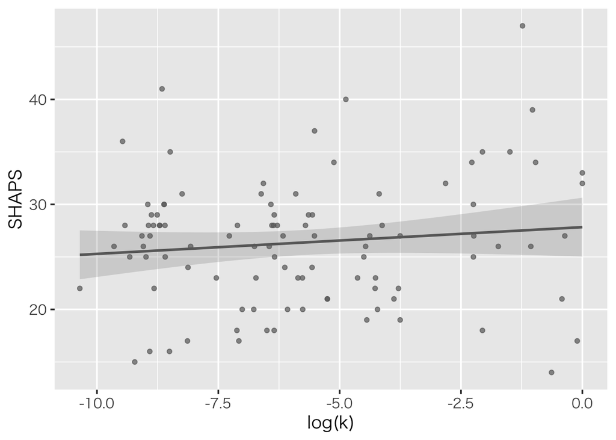

```r
# 散布図を作成
temp %>%
  ggplot(aes(x = log(k_hdf), y = shaps)) +
  geom_point(colour = "dimgray", alpha = 0.7) +
  geom_smooth(method = "lm",
              colour = "dimgray", fill = "dimgray", alpha = 0.2) +
  # windowsの場合はbase_family引数は削除
  theme_gray(base_size = 14, base_family = "HiraKakuPro-W3") +
  xlab("log(k)") + ylab("SHAPS")
```

## AICに基づいたモデル比較および相関分析

### AICを計算

```r
aic_hdf <- sum(2*dat$fvalmin_hdf + 2 * 2)
aic_exp <- sum(2*dat$fvalmin_exp + 2 * 2)
aic_qexp <- sum(2*dat$fvalmin_qexp + 2 * 3)

cat("HDF: ", aic_hdf, "\n", "EXP: ", aic_exp, "\n", "Qexp: ", aic_qexp)
```

```
## HDF:  -5.560328e+15
##  EXP:  -1.157208e+16
##  Qexp:  -6.380362e+14
```

### モデル比較

```r
aics <- c(aic_hdf, aic_exp, aic_qexp)

if(which(aics == min(aics)) == 1){
  model <- "k_hdf"
}
if(which(aics == min(aics)) == 2){
  model <- "k_exp"
}
if(which(aics == min(aics)) == 3){
  model <- "k_qexp"
}

cat("Best model is: ", model)
```

```
## Best model is:  k_exp
```

### 相関分析

```r
# 割引率が0に推定されてしまった参加者がいた場合にそのデータを除外する
temp <- dat %>%
  select(model, shaps) %>%
  filter_(paste(model, "!=", 0))
cor.test(log(temp[,1]), temp[,2])
```

```
##
##  Pearson's product-moment correlation
##
## data:  log(temp[, 1]) and temp[, 2]
## t = 1.7281, df = 100, p-value = 0.08707
## alternative hypothesis: true correlation is not equal to 0
## 95 percent confidence interval:
##  -0.02502181  0.35306468
## sample estimates:
##       cor
## 0.1702817
```

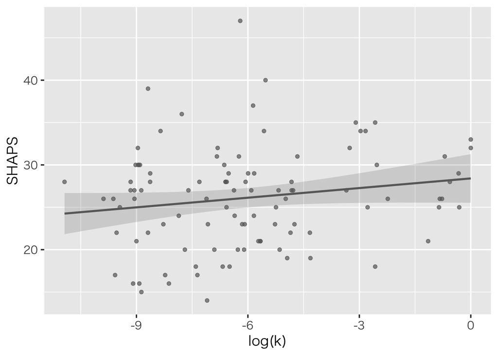

```r
temp %>%
  ggplot(aes(x = log(temp[,1]), y = temp[,2])) +
  geom_point(colour = "dimgray", alpha = 0.7) +
  geom_smooth(method = "lm",
              colour = "dimgray", fill = "dimgray", alpha = 0.2) +
  # windowsの場合はbase_family引数は削除
  theme_gray(base_size = 14, base_family = "HiraKakuPro-W3") +
  xlab("log(k)") + ylab("SHAPS")
```

## R2によるモデルの当てはまりの検討

### モデルの予測値を追加

```r
dat <- dat %>%
  mutate(d0_iv_hdf_pred = 1000/(1+k_hdf*0),
         d2_iv_hdf_pred = 1000/(1+k_hdf*2),
         d30_iv_hdf_pred = 1000/(1+k_hdf*30),
         d180_iv_hdf_pred = 1000/(1+k_hdf*180),
         d365_iv_hdf_pred = 1000/(1+k_hdf*365),
         d0_iv_exp_pred = 1000*exp(-1*k_exp*0),
         d2_iv_exp_pred = 1000*exp(-1*k_exp*2),
         d30_iv_exp_pred = 1000*exp(-1*k_exp*30),
         d180_iv_exp_pred = 1000*exp(-1*k_exp*180),
         d365_iv_exp_pred = 1000*exp(-1*k_exp*365),
         d0_iv_qexp_pred = 1000/((1+(1-q_qexp)*k_qexp*0))^(1/(1-q_qexp)),
         d2_iv_qexp_pred = 1000/((1+(1-q_qexp)*k_qexp*2))^(1/(1-q_qexp)),
         d30_iv_qexp_pred = 1000/((1+(1-q_qexp)*k_qexp*30))^(1/(1-q_qexp)),
         d180_iv_qexp_pred = 1000/((1+(1-q_qexp)*k_qexp*180))^(1/(1-q_qexp)),
         d365_iv_qexp_pred = 1000/((1+(1-q_qexp)*k_qexp*365))^(1/(1-q_qexp)))
```

### R2を計算する関数を作成

```r
calcu_R2 <- function(data){
  # R2を計算する
  #
  # Args:
  # data: 参加者1人分のデータ
  #
  # Return:
  # 参加者1人分のR2

  # IVおよびIVの予測値, A, Dを抜き出す
  iv <- data %>%
    select(d0_iv:d365_iv) %>%
    as.numeric() # ベクトル化
  A <- 1000
  D <- c(0, 2, 30, 180, 365)

  # 双曲割引関数による予測値を計算
  iv_hdf <- data %>%
    select(d0_iv_hdf_pred:d365_iv_hdf_pred) %>%
    as.numeric()

  # 指数関数による予測値を計算
  iv_exp <- data %>%
    select(d0_iv_exp_pred:d365_iv_exp_pred) %>%
    as.numeric()

  # q-指数関数による予測値を計算
  iv_qexp <- data %>%
    select(d0_iv_qexp_pred:d365_iv_qexp_pred) %>%
    as.numeric()

  # R2を計算しデータに結合
  data <- data %>%
    mutate(R2_hdf = 1-sum((iv-iv_hdf)^2)/sum((iv)^2),
           R2_exp = 1-sum((iv-iv_exp)^2)/sum((iv)^2),
           R2_qexp = 1-sum((iv-iv_qexp)^2)/sum((iv)^2),
           meanR2 = mean(c(R2_hdf, R2_exp, R2_qexp))) # 可視化する際に使用

  return(data)
}
```

### R2を比較

双曲割引関数, 指数関数, q-指数関数それぞれについて, 予測値をもとにR2値を算出し, 元データに結合する。

```r
dat <- dat %>%
  split(.$id) %>%
  map_dfr(calcu_R2)

cat("HDF: ", mean(dat$R2_hdf), "\n",
    "EXP: ", mean(dat$R2_exp), "\n",
    "QEXP: ", mean(dat$R2_qexp))
```

```
## HDF:  0.6750861
##  EXP:  0.6843533
##  QEXP:  0.6112414
```

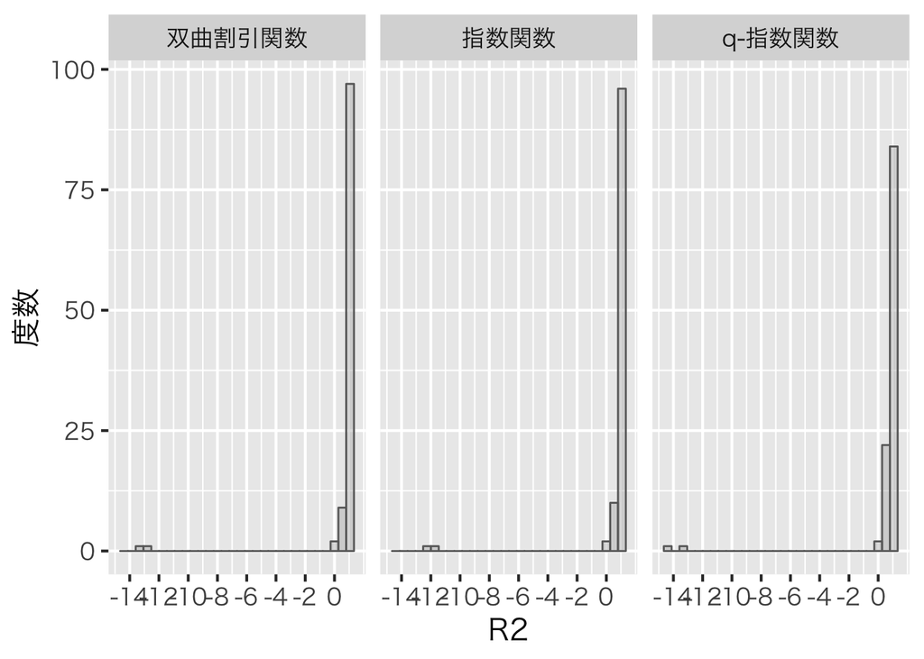

```r
dat %>%
  select(id, R2_hdf, R2_exp, R2_qexp) %>%
  gather(key = model, value = R2, -id) %>%
  mutate(model = recode(model,
                        "R2_hdf" = "双曲割引関数",
                        "R2_exp" = "指数関数",
                        "R2_qexp" = "q-指数関数") %>%
           as.factor() %>%
           fct_relevel("双曲割引関数", "指数関数", "q-指数関数")) %>%
  ggplot() +
  geom_histogram(aes(x = R2),
                 alpha = 0.5, colour = "dimgray", fill = "gray") +
  scale_x_continuous(breaks = seq(-20, 1, 2)) +
  xlab("R2") + ylab("度数") +
  # windowsの場合はbase_family引数は削除
  theme_gray(base_size = 16, base_family = "HiraKakuPro-W3") +
  facet_wrap(~model)
```

## 可視化によるモデルの当てはまりの検討

双曲割引関数, 指数関数, q-指数関数の3つのモデルにおけるR2値の平均が最大の参加者および最小の参加者それぞれについて, 縦軸をIV, 横軸を遅延時間とし, 観測値に対する予測値の当てはまり度合いを検討する。なお, 各点を観測値, 実線を予測値とする。

### HDF

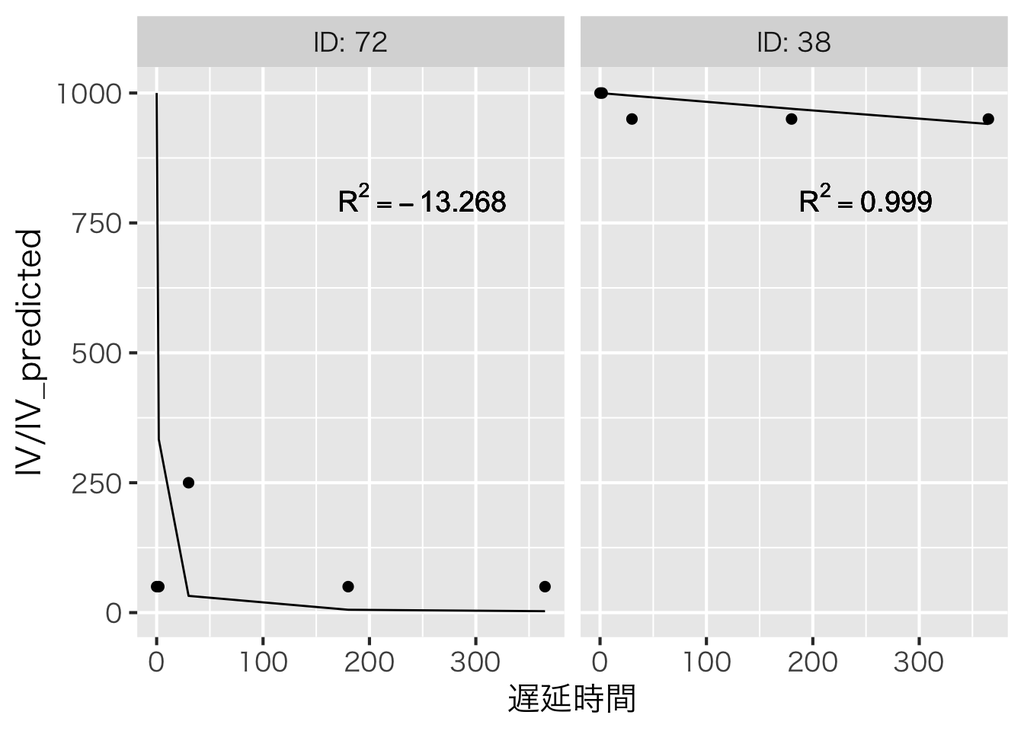

```r
dat %>%
  filter(meanR2 %in% c(max(meanR2), min(meanR2))) %>%
  arrange(meanR2) %>%
  select(id, d0_iv, d2_iv, d30_iv, d180_iv, d365_iv, R2_hdf) %>%
  mutate(id = paste("ID: ", id, sep = "") %>%
           factor() %>%
           fct_inorder()) %>%
  gather(key = delay, value = iv, -id, -R2_hdf) %>%
  mutate(pred = dat %>%
           filter(meanR2 %in% c(max(meanR2), min(meanR2))) %>%
           arrange(meanR2) %>%
           select(id, R2_hdf,
                  d0_iv_hdf_pred, d2_iv_hdf_pred, d30_iv_hdf_pred,
                  d180_iv_hdf_pred, d365_iv_hdf_pred) %>%
           gather(key = delay, value = pred, -id, -R2_hdf) %>%
           pull(pred),
         delay = recode(delay,
                        "d0_iv" = 0,
                        "d2_iv" = 2,
                        "d30_iv" = 30,
                        "d180_iv" = 180,
                        "d365_iv" = 365),
         # expression表現にするために値を作成
         R2_hdf = paste("R^2", "==", round(R2_hdf, 3), sep = "")) %>%
  ggplot() +
  geom_point(aes(x = delay, y = iv),
             size = 2) +
  geom_line(aes(x = delay, y = pred)) +
  geom_text(aes(x = 250, y = 800, label = R2_hdf),
            size = 5, parse = TRUE) +
  # windowsの場合はbase_family引数は削除
  theme_gray(base_size = 16, base_family = "HiraKakuPro-W3") +
  xlab("遅延時間") + ylab("IV/IV_predicted") +
  facet_wrap(~id)
```

### EXP

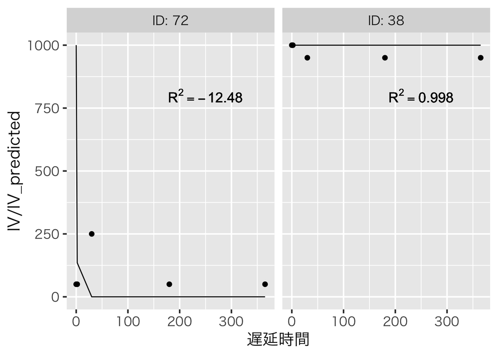

```r
dat %>%
  filter(meanR2 %in% c(max(meanR2), min(meanR2))) %>%
  arrange(meanR2) %>%
  select(id, d0_iv, d2_iv, d30_iv, d180_iv, d365_iv, R2_exp) %>%
  mutate(id = paste("ID: ", id, sep = "") %>%
           factor() %>%
           fct_inorder()) %>%
  gather(key = delay, value = iv, -id, -R2_exp) %>%
  mutate(pred = dat %>%
           filter(meanR2 %in% c(max(meanR2), min(meanR2))) %>%
           arrange(meanR2) %>%
           select(id, R2_exp,
                  d0_iv_exp_pred, d2_iv_exp_pred, d30_iv_exp_pred,
                  d180_iv_exp_pred, d365_iv_exp_pred) %>%
           gather(key = delay, value = pred, -id, -R2_exp) %>%
           pull(pred),
         delay = recode(delay,
                        "d0_iv" = 0,
                        "d2_iv" = 2,
                        "d30_iv" = 30,
                        "d180_iv" = 180,
                        "d365_iv" = 365),
         # expression表現にするために値を作成
         R2_exp = paste("R^2", "==", round(R2_exp, 3), sep = "")) %>%
  ggplot() +
  geom_point(aes(x = delay, y = iv),
             size = 2) +
  geom_line(aes(x = delay, y = pred)) +
  geom_text(aes(x = 250, y = 800, label = R2_exp),
            size = 5, parse = TRUE) +
  # windowsの場合はbase_family引数は削除
  theme_gray(base_size = 16, base_family = "HiraKakuPro-W3") +
  xlab("遅延時間") + ylab("IV/IV_predicted") +
  facet_wrap(~id)
```

### Qexp

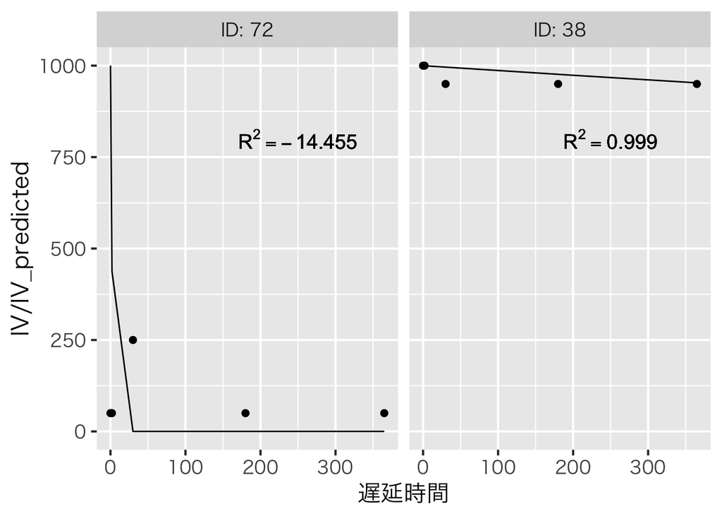

```r
dat %>%
  filter(meanR2 %in% c(max(meanR2), min(meanR2))) %>%
  arrange(meanR2) %>%
  select(id, d0_iv, d2_iv, d30_iv, d180_iv, d365_iv, R2_qexp) %>%
  mutate(id = paste("ID: ", id, sep = "") %>%
           factor() %>%
           fct_inorder()) %>%
  gather(key = delay, value = iv, -id, -R2_qexp) %>%
  mutate(pred = dat %>%
           filter(meanR2 %in% c(max(meanR2), min(meanR2))) %>%
           arrange(meanR2) %>%
           select(id, R2_qexp,
                  d0_iv_qexp_pred, d2_iv_qexp_pred, d30_iv_qexp_pred,
                  d180_iv_qexp_pred, d365_iv_qexp_pred) %>%
           gather(key = delay, value = pred, -id, -R2_qexp) %>%
           pull(pred),
         delay = recode(delay,
                        "d0_iv" = 0,
                        "d2_iv" = 2,
                        "d30_iv" = 30,
                        "d180_iv" = 180,
                        "d365_iv" = 365),
         # expression表現にするために値を作成
         R2_qexp = paste("R^2", "==", round(R2_qexp, 3), sep = "")) %>%
  ggplot() +
  geom_point(aes(x = delay, y = iv),
             size = 2) +
  geom_line(aes(x = delay, y = pred)) +
  geom_text(aes(x = 250, y = 800, label = R2_qexp),
            size = 5, parse = TRUE) +
  # windowsの場合はbase_family引数は削除
  theme_gray(base_size = 16, base_family = "HiraKakuPro-W3") +
  xlab("遅延時間") + ylab("IV/IV_predicted") +
  facet_wrap(~id)
```

## AUCを用いた相関分析

### AUCを計算する関数を作成

```r
calcu_auc <- function(data){
  # AUCを計算する
  #
  # Args:
  # data: 参加者1人分のデータ
  #
  # Return:
  # 参加者1人分のAUC

  # 参加者1人分のIVおよびDを抜き出す
  iv <- data %>%
    select(d0_iv:d365_iv) %>%
    as.numeric() *100
  D <- c(0, 2, 30, 180, 365)

  # AUCが0-1になるように, IVおよびDを正規化
  iv <- iv/1000
  D <- D/365

  # AUCを計算
  temp <- sum(diff(D) * (iv[-1] + iv[-length(iv)]))/2

  data <- data %>%
    mutate(auc = temp)

  return(data)
}
```

### AUCを計算

AUCを算出し元データに結合する。

```r
dat <- dat %>%
  split(.$id) %>%
  map_dfr(calcu_auc)
```

### 相関分析

```r
cor.test(dat$auc, dat$shaps)
```

```
##
##  Pearson's product-moment correlation
##
## data:  dat$auc and dat$shaps
## t = -1.2154, df = 108, p-value = 0.2269
## alternative hypothesis: true correlation is not equal to 0
## 95 percent confidence interval:
##  -0.29693941  0.07266574
## sample estimates:
##        cor
## -0.1161562
```

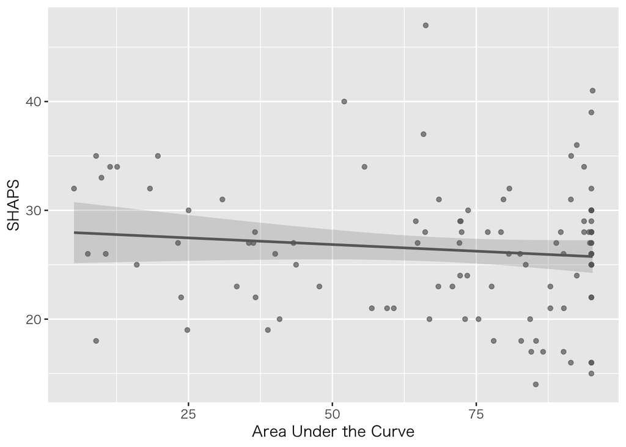

```r
dat %>%
  ggplot(aes(x = auc, y = shaps)) +
  geom_point(colour = "dimgray", alpha = 0.7) +
  geom_smooth(method = "lm",
              colour = "dimgray", fill = "dimgray", alpha = 0.2) +
  # windowsの場合はbase_family引数は削除
  theme_gray(base_size = 12, base_family = "HiraKakuPro-W3") +
  xlab("Area Under the Curve") + ylab("SHAPS")
```